# MIE237

2016-01-19

## Inference with two independent numerical samples (9.8 and 10.5) continued…

## Alternative "design" for inference on mean differences

- By "design" I mean the specific plan to gather a sample.
- So far the design was motivated by the problem: two populations, two means (and variances), interest in the difference between the mean. Plan: gather two independent samples.
- That's not the only way to learn about a mean difference.
- The sampling plan might instead involve collecting pairs \(\left((Y_{11}, Y_{21}), (Y_{12}, Y_{22}), \ldots, (Y_{1n}, Y_{2n})\right)\) (that are likely to be positively correlated.)
- In which case the correct analysis is to consider what is effectively a single sample \(Y_{d_1}, Y_{d_2},\ldots, Y_{d_n}\) with \(Y_{d_i} = Y_{1i}-Y_{2i}\)

## "Paired observations" (9.9 and part of 10.5)

- The model reduces to \(Y_{d_i} = \mu_d + \varepsilon_i \text{ with } \varepsilon_i \sim N\left(\mu_d, \sigma_d^2\right)\).
- The analysis is then just a good ol' one sample \(t\) test/interval.
- The book possibly doesn't make this clear enough: **The analysis must follow the model/sampling plan**

## Example: 9.92

"…Calcium is a required element for plants and animals. The amount taken upand stored in plants is closely correlated to the amount present in the soil. Itwas hypothesized that a fire may change the calcium levels present in the soil and thus affect the amount available to deer.

A large tract of land in the Fishburn Forest was selected for a prescribed burn.Soil samples were taken from 12 plots of equal area just prior to the burn andanalyzed for calcium. Postburn calcium levels were analyzed from the same plots."

## Example: 9.92 (with a small dose of reality)

```r
library(rio)
burn <- import("Ex09.92.txt")
```

```
## Error in fread(input = file, sep = sep, sep2 = "auto", header = header, : Expecting 2 cols, but line 10 contains text after processing all cols. It is very likely that this is due to one or more fields having embedded sep='  ' and/or (unescaped) '\n' characters within unbalanced unescaped quotes.…
```

Hmm.

## Example: 9.92

```r
burn <- import("Ex09.92.txt", fread=FALSE) # Seems OK
```

[output not shown]

```r
t.test(burn_diff$calcium_diff)
```

```
##
##  One Sample t-test
##
## data:  burn_diff$calcium_diff
## t = 8.9028, df = 11, p-value = 2.331e-06
## alternative hypothesis: true mean is not equal to 0
## 95 percent confidence interval:
##  30.55020 50.61646
## sample estimates:
## mean of x
##  40.58333
```

## Model assumptions

Just the normality assumption (on the differences) - all OK.

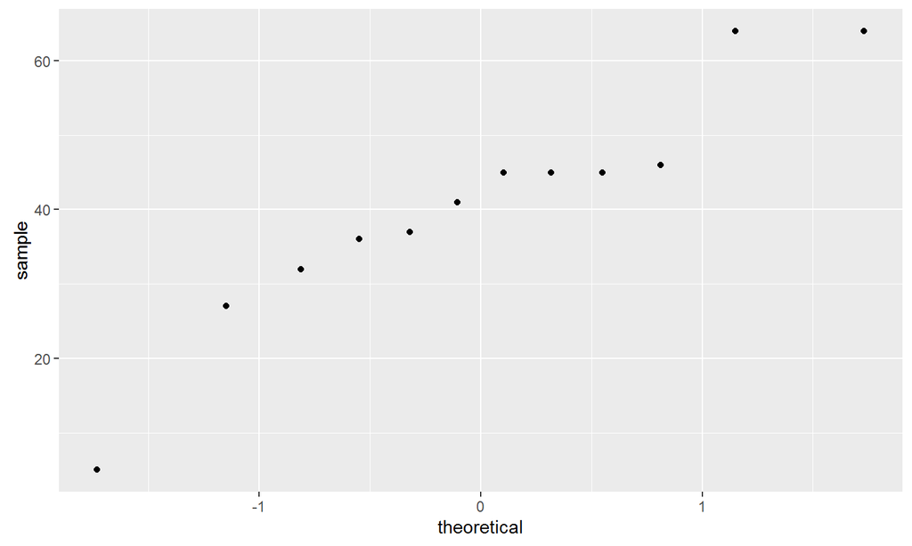

## The Wrong Analysis

```r
t.test(burn$Preburn, burn$Postburn)
```

```
##
##  Welch Two Sample t-test
##
## data:  burn$Preburn and burn$Postburn
## t = 6.4623, df = 18.112, p-value = 4.303e-06
## alternative hypothesis: true difference in means is not equal to 0
## 95 percent confidence interval:
##  27.39532 53.77135
## sample estimates:
## mean of x mean of y
##  57.50000  16.91667
```

## Cause of the difference

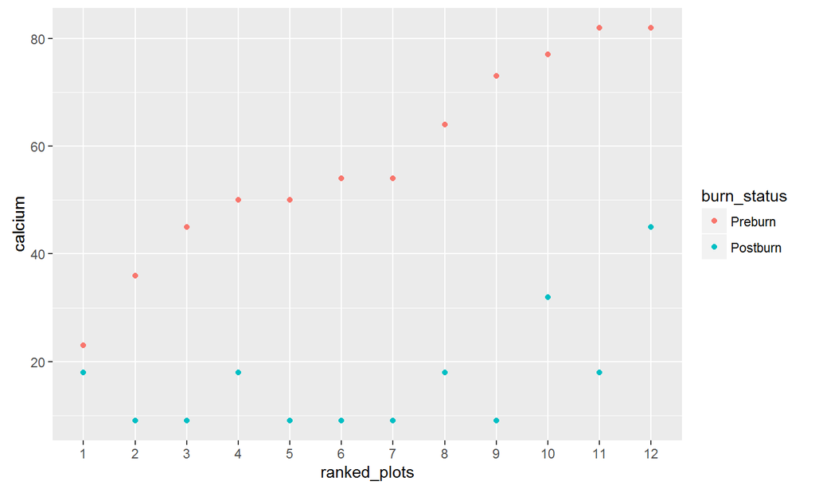

## Extreme example

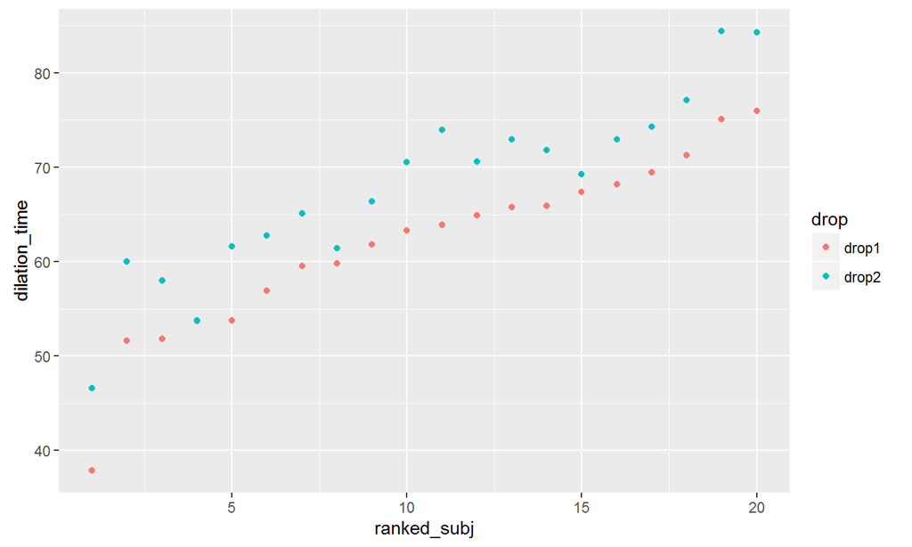

## Extreme example - correct

```r
t.test(eye_drops$drop1 - eye_drops$drop2)
```

```
##
##  One Sample t-test
##
## data:  eye_drops$drop1 - eye_drops$drop2
## t = -10.231, df = 19, p-value = 3.636e-09
## alternative hypothesis: true mean is not equal to 0
## 95 percent confidence interval:
##  -7.204020 -4.757151
## sample estimates:
## mean of x
## -5.980585
```

## Extreme example - wrong

```r
t.test(eye_drops$drop1, eye_drops$drop2)
```

```
##
##  Welch Two Sample t-test
##
## data:  eye_drops$drop1 and eye_drops$drop2
## t = -2.0299, df = 37.942, p-value = 0.04942
## alternative hypothesis: true difference in means is not equal to 0
## 95 percent confidence interval:
##  -11.9451916  -0.0159793
## sample estimates:
## mean of x mean of y
##  61.90524  67.88582
```